# Week 4 - Clustering

Gareth Gillard, Lars Grønvold, Niklas Mähler, Torgeir R. Hvidsten

Last change: 21.09.2024

## Introduction

In this lab we will continue using the AspWood data from previous labs. We will look at different clustering methods that can be used for discovering natural groupings in data.

**OBS**: Some parts of this exercise is a tutorial where you only have to copy and run the code. Don’t be content with that: try to understand what the code does! In the R Markdown report, only include code and results that are needed to document what you are asked to produce yourself (in red). Also remember to answer all questions in red.

## Loading the data

We’ll again be using the data from the so-called AspWood study of [Sundell et al.](https://academic.oup.com/plcell/article/29/7/1585/6099151). While differential expression analysis (Lab 3) is performed on count data, other down-stream analysis such as clustering, machine learning and network analysis are conducted on log2-transformed expression values or VST data.

Here we will use the normalized RNA-seq data from Lab 2. If you don’t have the data files, you can download *AspWood_normalized.RData* from Canvas.

```r
# Load data
load("../Week2/AspWood_normalized.RData")
```

These file contain the following objects:

- **`dds`:** An `DESeqDataSet`-object of count data from all samples, including normalization factors.
- **`vst`:** A matrix of VST-normalized expression values.

We will focus on the vst-data in this lab. In week 2, we removed genes with less than 10 reads, but we are still leaft with 37075 genes. Since some of the algorithms we use in this lab is rather time and memory consuming, we will work one a smaller set of genes here:

```r
vst %>%
  as.data.frame() %>%
  rownames_to_column(var = "Gene") %>%
  pivot_longer(-Gene, names_to = "Sample", values_to = "Expression") %>%
  mutate(Expressed = Expression > 5,
         Silent = Expression < 1) %>%
  group_by(Gene) %>%
  summarise(Expressed = sum(Expressed),
            Silent = sum(Silent)) %>%
  filter(Expressed >= 1, Silent >= 1) %>%
  pull(Gene) -> regulated.genes

aspwood <- vst[rownames(vst) %in% regulated.genes,]

dim(aspwood)
```

```
## [1] 4131   25
```

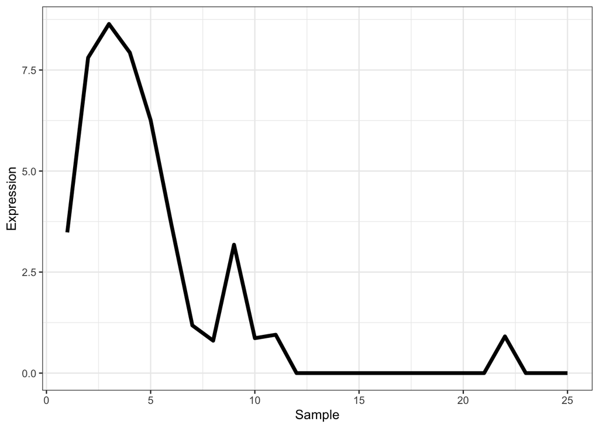

```r
# Plot the expression profile of a random gene
set.seed(3)

aspwood %>%
  as.data.frame() %>%
  rownames_to_column(var = "Gene") %>%
  filter(Gene == sample(regulated.genes, 1)) %>%
  pivot_longer(-Gene, names_to = "Sample", values_to = "Expression") %>%
  separate(Sample, into = c("Tree", "Sample"), sep = "-") %>%
  mutate(Sample = as.numeric(Sample)) %>%
  ggplot(aes(x = Sample, y = Expression)) +
  geom_line(linewidth = 1.5) +
  theme_bw()
```

```r
remove(dds, vst)
```

**Note**: The `set.seed` function with the same seed (`3` in this case) ensures that the code will select the same random gene every time. Changing the seed will produce another subset. Try it!

Briefly explain what the code above is doing.

## Hierarchical clustering

To be able to perform hierarchical clustering we must calculate a distance measure between our observations. This can be accomplished with the `dist` function. It will produce a triangular matrix of distances between all observations in our data given a distance function. A distance matrix can also be seen as a dissimilarity matrix since a larger distance between two observations means that they are more dissimilar.

### An example using the iris dataset

Let’s look at a small example using the built-in iris dataset. It is a dataset that consists of 150 samples from three classes of iris flowers with the measurements: sepal length, sepal width, petal length, petal width, and also, what class of flower the sample belongs to (*Iris setosa*, *Iris versicolor* or *Iris virginica*):

```r
iris[1:10,]
```

```
##    Sepal.Length Sepal.Width Petal.Length Petal.Width Species
## 1           5.1         3.5          1.4         0.2  setosa
## 2           4.9         3.0          1.4         0.2  setosa
## 3           4.7         3.2          1.3         0.2  setosa
## 4           4.6         3.1          1.5         0.2  setosa
## 5           5.0         3.6          1.4         0.2  setosa
## 6           5.4         3.9          1.7         0.4  setosa
## 7           4.6         3.4          1.4         0.3  setosa
## 8           5.0         3.4          1.5         0.2  setosa
## 9           4.4         2.9          1.4         0.2  setosa
## 10          4.9         3.1          1.5         0.1  setosa
```

For our example, we would like to investigate if it is possible to cluster the flowers according to flower class using only sepal and petal information (unsupervised analysis!). So we’ll remove the species data from the table and instead add it as row names:

```r
# Save our own version of the iris data
iris.data <- iris

# Save the species data
iris.species <- iris.data$Species

# Remove the species information (set as NULL) so that it doesn't influence the clustering
iris.data$Species <- NULL
```

First, we’ll need to create the distance matrix. Here, we have first installed the `usedist`-package as it gives us access to some useful functions such as `dist_subset()`.

```r
library(usedist)

# Calculate the distance matrix
# and show the first 5 rows/columns
iris.data %>%
  dist() %>%
  dist_subset(1:5)
```

```
##           1         2         3         4
## 2 0.5385165
## 3 0.5099020 0.3000000
## 4 0.6480741 0.3316625 0.2449490
## 5 0.1414214 0.6082763 0.5099020 0.6480741
```

The distance matrix is symmetric, i.e. $\mathbf{A}^\top = \mathbf{A}$. In practice it means that the distance is non-directional: sample $A$ is as dissimilar to sample $B$ as sample $B$ is dissimilar to sample $A$. A lower value means that the distance between the two samples is small, and therefore the diagonal contains only zeros. You can supply the `dist` function with different distance measures using the parameter `method`.

- What distance function does `dist` use as default?
- Does the `dist` function calculate distances between rows or columns?

Now we can perform the clustering based on the distance matrix. We’ll use the `hclust` function for this, and it takes a distance matrix as input.

- What hierarchical clustering method does `hclust` use as default?

```r
# Perform the hierarchical clustering
iris.tree <- iris.data %>%
  dist() %>%
  hclust()
```

Finally, we can plot the similarity tree `iris.tree` (also referred to as a dendrogram) using the default `plot`-function in R. However, first install the `dendextend`-package: it gives us access to some added functionality like the `set`-function. This function works on `dendrogram`-objects and not on `hclust`-objects (although these are largely similar), so we have to use the function `as.dendrogram()` first:

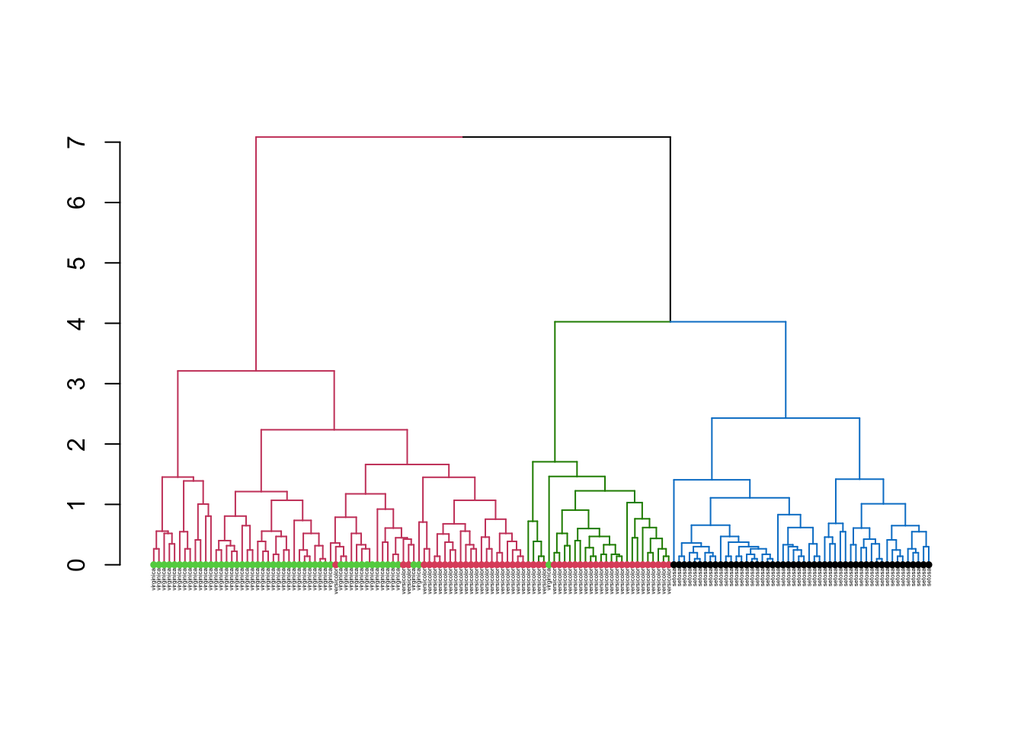

```r
library(dendextend)

iris.tree %>%
  as.dendrogram() %>%
  set("labels", iris.species[iris.tree$order]) %>% # change labels
  set("labels_cex", 0.25) %>% # label size
  set("leaves_pch", 19) %>%  # node point type
  set("leaves_cex", 0.5) %>%  # node point size
  set("leaves_col", iris.species[iris.tree$order]) %>%  # node point color
  set("branches_k_color", k=3) %>% # branch color
  plot()
```

*Note 1*: We did not specify which colors to use for branches and leaves, but this is of course possible. Experiment if you want (`?set`)! `iris.species` is a *factor*, and functions in R will translate the levels of factors into colors when appropriate.

*Note 2*: The leaves of the tree correspond to rows in the original `iris`-table, but they are obviously no longer in the same order as in the table. `iris.tree$order` gives us an index vector that we can use to reorder the rows so that we can color/label leaves from left to right correctly.

- Explain the difference between the coloring of the branches and the leaves of the tree? What is your interpretation?
- Optional: Feel free to experiment with other measures e.g.

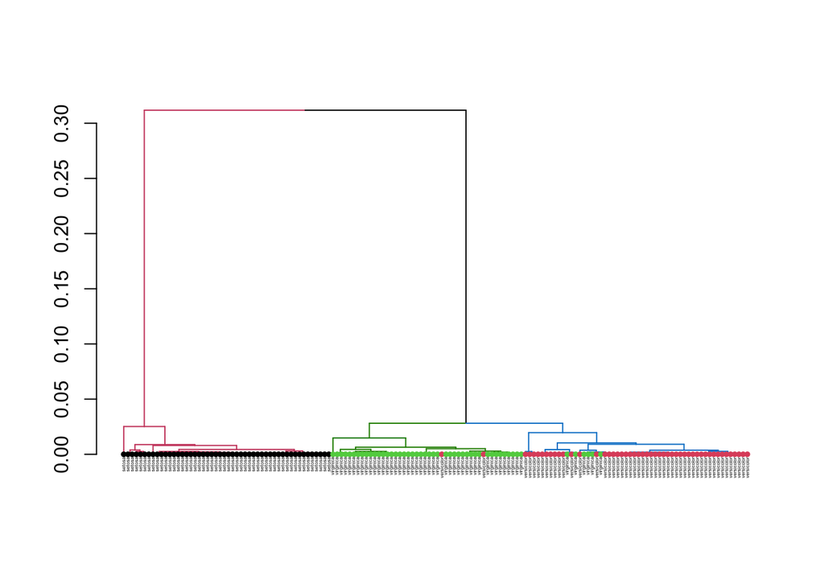

```r
iris.tree.alt <- iris.data %>%
  t() %>%
  cor() %>%
  (function(.) {1 - .}) %>%
  as.dist() %>%
  hclust(method = "average")

iris.tree.alt %>%
  as.dendrogram() %>%
  set("labels", iris.species[iris.tree.alt$order]) %>% # change labels
  set("labels_cex", 0.25) %>% # label size
  set("leaves_pch", 19) %>%  # node point type
  set("leaves_cex", 0.5) %>%  # node point size
  set("leaves_col", iris.species[iris.tree.alt$order]) %>%  # node point color
  set("branches_k_color", k=3) %>% # branch color
  plot()
```

*Note*: While `dist` computes the distance between rows in a matrix, `cor` computes the similarity (from -1 to 1) of *columns*. We therefore (1) have to transpose the matrix `t()` and (2) transform the correlation into a distance by computing `1-cor` (which makes it a distance between 0 and 2. Why?). This last step is surprisingly cumbersome in `tidyverse`. However, we can always create our own function: `(function(.) {1 - .})`. Remember that what we write between two pipes (i.e. `%>%`) is always a function. Our custom function takes what is piped in (`.`) and computes `1-.`. Another way of doing the same is `-(1,.)`. Yes, minus (`-`) is a function. We normally use it like this: `3-2`, but we can also use it like this `-(3,2)`.

### Hierarchical clustering of the AspWood data

Now we’ll apply hierarchical clustering to our AspWood gene expression data. We want to cluster the *samples* into groups, not the *genes*.

The samples are taken from different stages of wood formation. In the paper, the samples are annotated like this (by observing the cells in the samples using a microscope):

```r
aspwood.stages <- factor(c(rep("PhloemZone", 5), rep("ExpansionZone", 5), rep("SecondaryCellWallZone", 9), rep("LignificationZone", 6)))
```

*Note 1*: Remember that the normalized expression data are in the `aspwood`-table.

*Note 2*: The `dist` function calculates the distances between *rows*. In the AspWood expression data, our samples are columns, so we need to rotate the table using the transpose function `t()`, *before* we pass it to the `dist` function.

*Note 3*: The same tree (dendrogram) can be drawn in many different ways. To draw a tree with samples ordered as close to the sampling order as possible (i.e. $01$, $02$, $03$, …, $25$), this code is very useful:

```r
aspwood.tree <- aspwood.tree %>%
  as.dendrogram() %>%
  reorder(1:25, agglo.FUN = mean) %>%
  as.hclust()
```

- Perform hierarchical clustering on the normalized expression data and draw the tree.

Compare the results to those in the AspWood paper. What is your biological interpretation of the tree?

## Heatmaps

### An example using the iris dataset

```r
# Install and load pheatmap package
install.packages("pheatmap")
library(pheatmap)
```

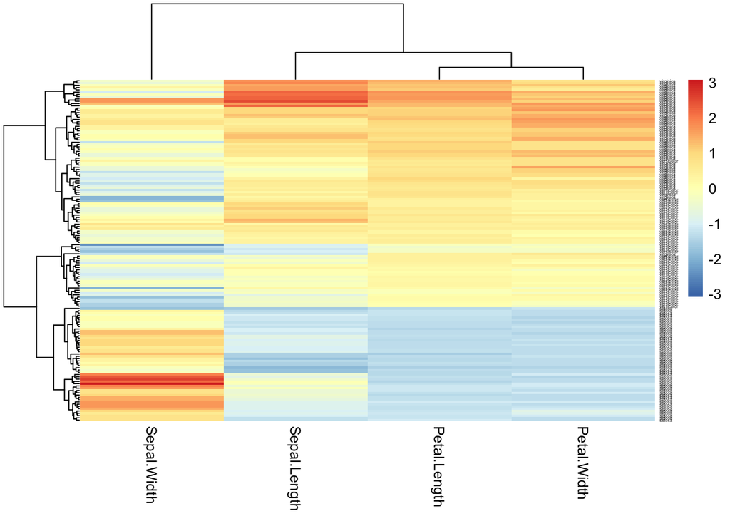

```r
pheatmap(as.matrix(iris.data),
         cluster_rows = iris.tree,
         cluster_cols = TRUE,
         scale = "column",
         labels_row = as.character(iris.species),
         fontsize_row = 3)
```

*Note*: We can either use the default method for clustering (`cluster_cols = TRUE`, default is `TRUE` so we could skip this line) or specify a premade tree (`cluster_rows = iris.tree`). Performing the clustering outside `pheatmap` allows us to e.g. use `reorder` as in the AspWood-clustering above.

Check out `?pheatmap` for more arguments. You can for example specify the distance measure and clustering methods for both rows and columns.

We can also add color bars that correspond to a certain characteristic of our plants. This will make it easier to identify patterns in the heatmap, especially since the labels are too small to read. In this case we color the rows by the species:

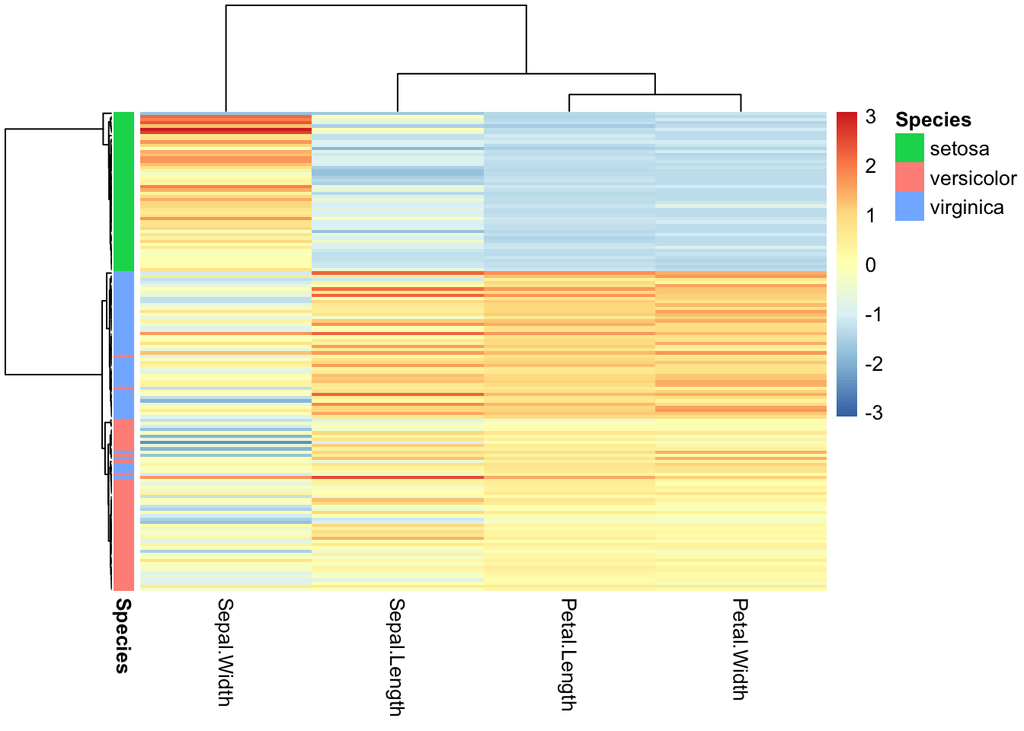

```r
# Create an annotation data.frame with the same row names as
# the input data (iris.data)
rownames(iris.data) <- 1:150 # OBS: iris did not have row names
annot.row <- data.frame(row.names = rownames(iris.data), Species = iris.species)

pheatmap(as.matrix(iris.data),
         cluster_rows = iris.tree.alt,
         cluster_cols = TRUE,
         scale = "column",
         show_rownames = FALSE,
         annotation_row = annot.row)
```

### Heatmap of the AspWood gene expression data

Now it is your turn. Perform the following two steps:

- Plot a heatmap of the AspWood gene expression data. Check in the method-section of the AspWood paper and use the same distance measures and clustering method. *OBS*: Should you scale rows or columns?
- Create an annotation `data.frame` with `row.names` equal to sample names and one column containing the `aspwood.stages`-vector. Then give this to the `annotation_col` parameter to color the different stages of wood formation.

Finally, interpret the results:

- Compare your plot with figure 1 in the Aspwood-paper. How well do they agree?
- What happens to the heatmap if you skip `scale = "row"` in the `pheatmap`-function? Explain.

## $k$-means clustering

The aim of $k$-means clustering is to partition the observations in to $k$ clusters. The algorithm will find centers for $k$ groups (centroids) and for each sample assign it to the group with the closest centroid.

### An example using the iris dataset

Again, we use the iris dataset for an example. Lets run the `kmeans` function on the iris dataset. Note that `kmeans` cluster rows in the input data.

```r
iris.kmeans <- kmeans(iris.data, 3)
```

Now we have a `kmeans`-object that we can explore to see how well the clustering performed based on the known species. For this we can use the `table` function to create a [confusion matrix][confusion]:

```r
table(iris.kmeans$cluster, iris.species, dnn = c("Cluster", "Class"))
```

```
##        Class
## Cluster setosa versicolor virginica
##       1      0          2        36
##       2     50          0         0
##       3      0         48        14
```

We can also try to plot these results. In the `kmeans`-results, we have an attribute called `centers` with the values for the center of each cluster. These are three points (because we look for three clusters) in a four-dimensional space:

```r
iris.kmeans$centers
```

```
##   Sepal.Length Sepal.Width Petal.Length Petal.Width
## 1     6.850000    3.073684     5.742105    2.071053
## 2     5.006000    3.428000     1.462000    0.246000
## 3     5.901613    2.748387     4.393548    1.433871
```

Since it’s not possible to plot in four dimensions, we will concentrate on only two variables: *sepal width* and *sepal length*:

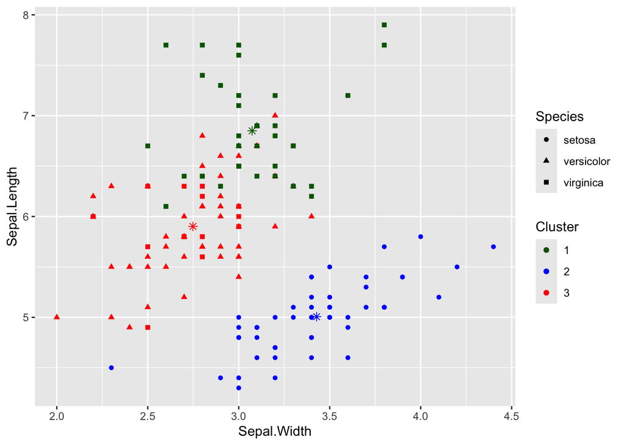

```r
iris.data %>%
  ggplot(aes(x = Sepal.Width, y = Sepal.Length,
             col = as.factor(iris.kmeans$cluster), shape = iris.species)) +
  scale_color_manual(values = c("darkgreen", "blue", "red")) +
  labs(col = "Cluster", shape = "Species") +
  geom_point() +
  annotate("point", x = iris.kmeans$centers[1,2], y = iris.kmeans$centers[1,1],
           col="darkgreen", size = 2, shape = 8) +
  annotate("point", x = iris.kmeans$centers[2,2], y = iris.kmeans$centers[2,1],
           col="blue", size = 2, shape = 8) +
  annotate("point", x = iris.kmeans$centers[3,2], y = iris.kmeans$centers[3,1],
           col="red", size = 2, shape = 8)
```

The three colors represent the three different clusters identified by the $k$-means clustering, and the shape of the points correspond to the real class of the samples.

Remember that the clustering actually was performed in four dimensions. In two dimensions, you may see dots that are closer to a centroid with another color.

### $k$-means clustering of the AspWood gene expression data

Now, it is your turn:

- perform $k$-means clustering of the *samples* in the AspWood gene expression data. *OBS*: Are you clustering rows or columns? What should $k$ be?
- How well does the k-means clustering compare with the hierarchical clustering (Hint: Use `aspwood.stages`-vector from earlier)?

## Principal Component Analysis (PCA)

### An example using the iris dataset

Principal component analysis (PCA) is a useful dimensionality reduction technique. In the Iris data, the number of dimensions is equal to the number of columns (*4*). PCA is done by mapping the data into a lower dimensional space, where the first principal component is the one that explains most of the variation in the data, the second explains the second most, and so on. The recommended function to use for PCA is `prcomp`. The returned value of `prcomp` is a `prcomp`-object which has an attribute `x`. `x` is a numerical matrix where each row corresponds to a plant and each column corresponds to a principal component.

Let’s try this with the iris dataset. First, we’ll compute the PCA:

```r
# PCA of iris data
iris.pca <- prcomp(iris.data)

# Summary of components
summary(iris.pca)
```

```
## Importance of components:
##                           PC1     PC2    PC3     PC4
## Standard deviation     2.0563 0.49262 0.2797 0.15439
## Proportion of Variance 0.9246 0.05307 0.0171 0.00521
## Cumulative Proportion  0.9246 0.97769 0.9948 1.00000
```

As you can see, we have four components in our results that together explain 100% of the variance. Next, we’ll plot the plants using the first two components to see if we get a good separation of the three species. As mentioned above, the principal components can be found in the attribute `x` of the `prcomp` object.

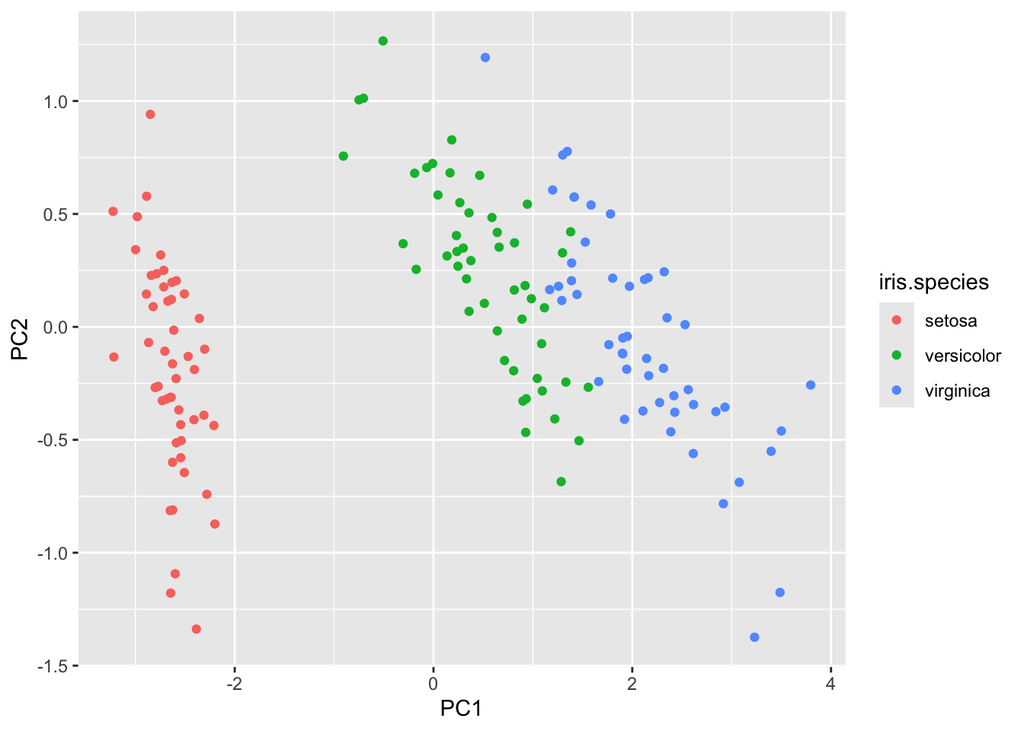

```r
iris.pca$x %>%
  ggplot(aes(PC1, PC2, col = iris.species)) +
  geom_point()
```

Take a moment to appreciate what the PCA-plot is. We previously plotted the samples using `Sepal.width` and `Sepal.length` as axis. But why not `Petal.width` and `Petal.length`, or any other of the six pairs of variables? This decision is exactly what PCA helps us with! PCA finds new variables (PCs) that preserves as much information (variance) in the data as possible. You can find out how much each original variable contributed to each PC like this:

```r
iris.pca$rotation
```

```
##                      PC1         PC2         PC3        PC4
## Sepal.Length  0.36138659 -0.65658877  0.58202985  0.3154872
## Sepal.Width  -0.08452251 -0.73016143 -0.59791083 -0.3197231
## Petal.Length  0.85667061  0.17337266 -0.07623608 -0.4798390
## Petal.Width   0.35828920  0.07548102 -0.54583143  0.7536574
```

Here we can see that `Petal.length` is the most influential variables for *PC1* while `Sepal.Width` is the most influential for *PC2*. Let’s redo the *k-means*-plot with these two variables:

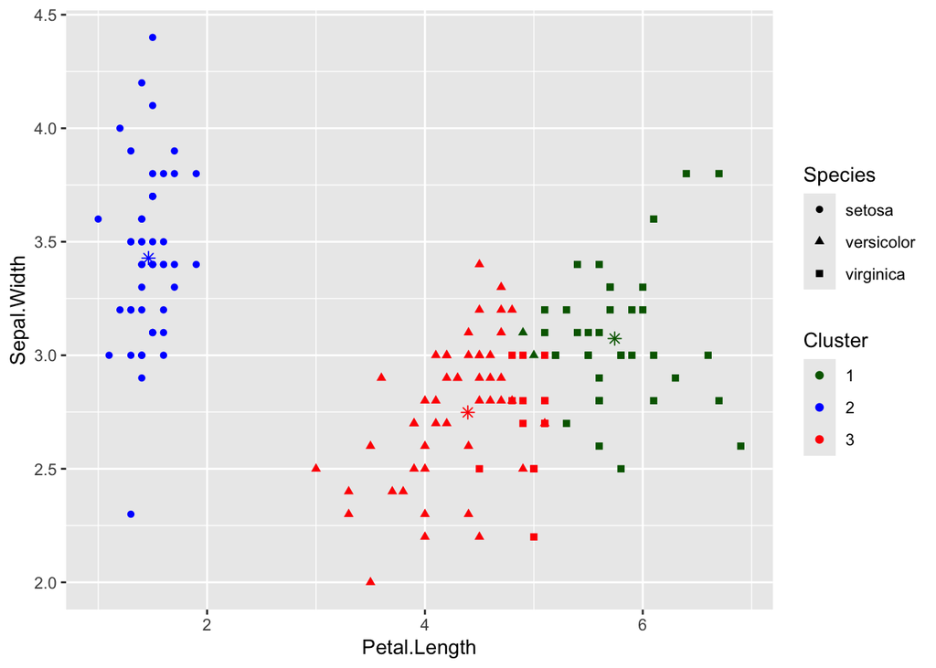

Better?

### PCA on the AspWood gene expression data

Now it’s your turn:

- Run PCA on the AspWood gene expression data.
- Create a scatterplot with the first two components. Color the points by the stages of wood formation as before.
- How large proportion of the variance do the first two components explain?